# Neural Progenitor Cells for Treatment of Spinal Cord Injury

# *Gene expression of pro-inflammatory cytokines/chemokines*

## Pro-inflammation over time

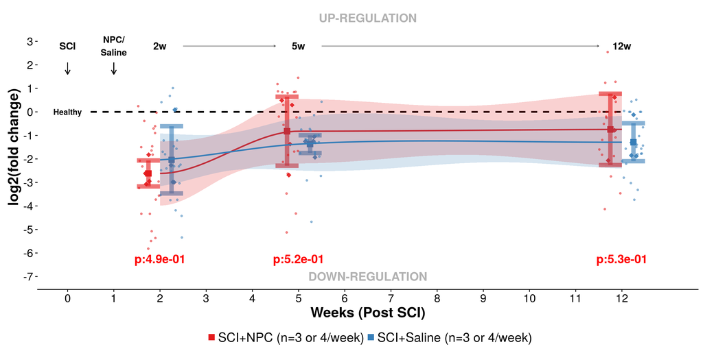

**Figure 1.** Figure log2(fold change in expression in relation to mean expresion in healthy control) of pro-inflammatory cytokines/chemokines (GM-CSF, IL12p35, IL1a, IL1b, MIP1a, TNFa) over time for each treatment group. P-values for independent two group comparison is presented at each time point. Color of p-value is green if p-value < 0.05, orange if p-value > 0.05 & p-value < 0.1 and red if p-value >0.1. Test is selected based on evaluation of assumptions.

## Individual cytokines/chemokines over time

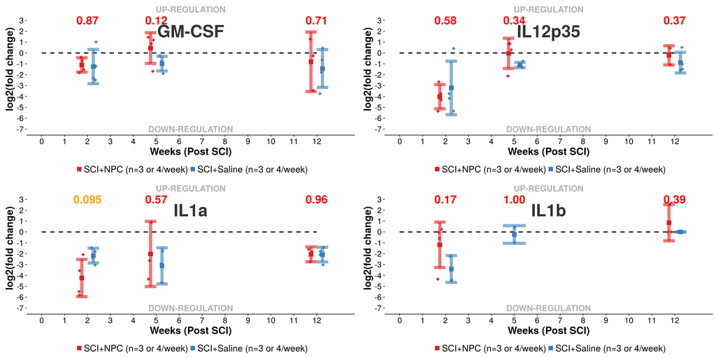

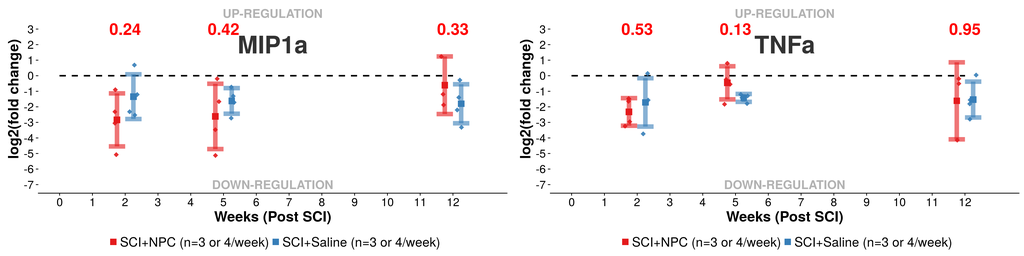

**Figure 2:** Each plot reports log2(fold change in expression in relation to mean expresion in healthy control) of one cytokine. P-values for comparison of the two independent groups are presented at each time point. Color of p-value is green if p-value < 0.05, orange if p-value > 0.05 & p-value < and red if p-value > 0.1.

## Heatmap 2 weeks post SCI

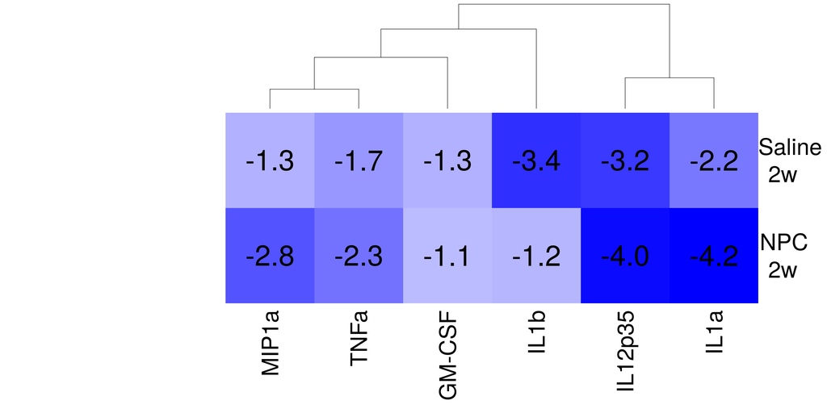

## Heatmap 5 weeks post SCI

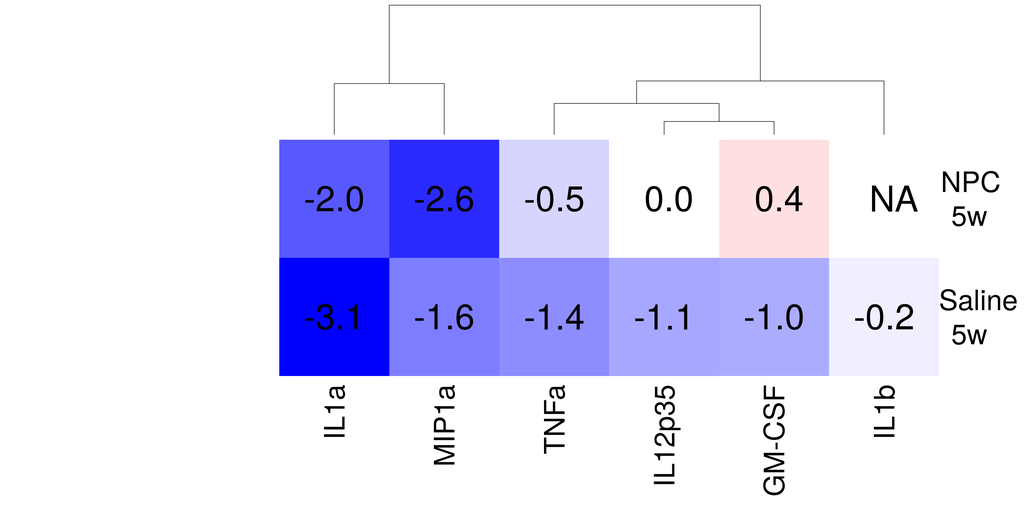

## Heatmap 12 weeks post SCI

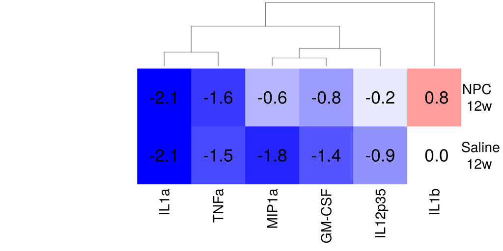

## Heatmap 2, 5 and 12 weeks post SCI

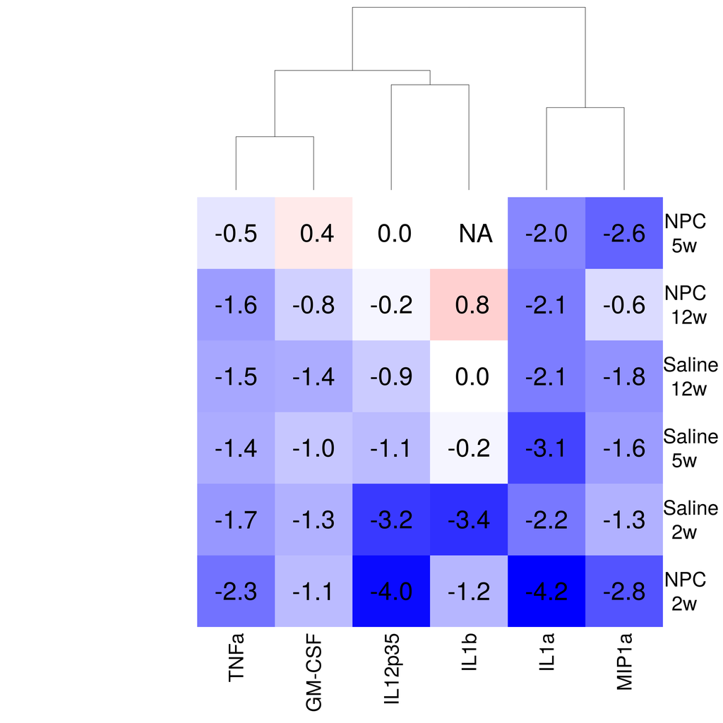

| Week | P-value |
| --- | --- |
| 2 | 0.487 |
| 5 | 0.523 |
| 12 | 0.531 |

**Table 1.** P-values for comparison of pro-inflammation between treatments within week.

| Treatment | P-value |
| --- | --- |
| NPC | 0.105 |
| saline | 0.528 |

**Table 2.** P-values for comparison of pro-inflammation within treatment between weeks.

| Target | 2 | 5 | 12 |
| --- | --- | --- | --- |
| GM-CSF | 0.871 | 0.124 | 0.711 |
| IL12p35 | 0.582 | 0.343 | 0.373 |
| IL1a | 0.095 | 0.567 | 0.961 |
| IL1b | 0.166 | 1.000 | 0.386 |
| MIP1a | 0.237 | 0.420 | 0.326 |
| TNFa | 0.527 | 0.133 | 0.950 |

**Table 3.** P-values for difference in expression of cytokine/chemokine between treatments within week.